# User’s Guide of *paslincs* Package - Identify Target Pathway

# Identify target pathway

The major application of our pasLINCS method is to identify the pathway(s) whose activity is modified after a perturbation based on the transcriptional signature (TS). This is done by correlating the TS with precomputed Pathways Activity Signatures (PASes). Here we demonstrate the use of the paslincs package in identifying the affected pathways by two example transcriptional signatures, a signature of amino acid starvation and a LINCS signature of chemical perturbagen, respectively.

Before running any analysis, we load the package and data.Then we associate the signature in each example to the PASes, and print of the summary of the analysis.

**Load the *paslincs* package:**

```r
library(paslincs)
```

**Load the pre-computed PAS of a cell line (e.g. MCF7 cell line):**

```r
PAS_MCF7 <- PathSigTableList$MCF7
head(PAS_MCF7[,1:5])
```

|  | GeneSymbol | hsa01521 | hsa01522 | hsa01523 | hsa01524 |
| --- | --- | --- | --- | --- | --- |
| 1 | PSME1 | NA | NA | NA | 2.338352 |
| 2 | ATF1 | NA | NA | NA | NA |
| 3 | RHEB | NA | NA | NA | NA |
| 4 | FOXO3 | NA | NA | NA | NA |
| 5 | RHOA | NA | NA | NA | NA |
| 6 | IL1B | 2.876833 | NA | NA | -2.914939 |

**Load all pathway names for annotating:**

```r
AllPathwayName <- unique(AllEdges[,c("Pathway","PathwayName")])
rownames(AllPathwayName) <- AllPathwayName$Pathway
```

### Example I: perturbation signature of amino acid starvation

In this example, we illustrate the analysis using the perturbation signatures of amino acid starvation.

**Load the signature of amino acid starvation constructed using the GSE62673 GEO dataset:**

```r
load(url("http://eh3.uc.edu/genomics/GenomicsPortals/ilincs/paslincs/GSE62673_mcf7_signatures.Rdata"),
     verbose = T)
```

```
## Loading objects:
##   MCF7_diff_expr
```

```r
head(MCF7_diff_expr[,1:2])
```

```
##        deprived.of.all.amino.acids-control.media
## A1CF                                   1.4347493
## A2M                                    1.1997007
## A4GALT                                 5.3951367
## A4GNT                                  0.6908553
## AAAS                                  -2.3797064
## AACS                                  -7.6909302
##        deprived.of.glutamine-control.media
## A1CF                            1.60579998
## A2M                            -0.51966954
## A4GALT                          1.93463048
## A4GNT                           0.01989912
## AAAS                            1.82086552
## AACS                           -8.24768461
```

**Corralate amino acid starvation signature with pre-computed PASes:**

```r
matchWithPas<-match(PAS_MCF7$GeneSymbol,rownames(MCF7_diff_expr))
corsWithPas<-cor(MCF7_diff_expr[na.omit(matchWithPas),"deprived.of.all.amino.acids-control.media"],
                 PAS_MCF7[!is.na(matchWithPas),-1],use="pairwise.complete.obs")
topPathways<-names(head(sort(abs(corsWithPas[1,]),decreasing = T),n=5))
topPathways
```

```
## [1] "hsa04151"   "hsa04924"   "hsa05010"   "hsa04662"   "hsa04150v2"
```

**Annotate results with pathway names:**

```r
data.frame(PathwayID=topPathways,PathwayName=AllPathwayName[topPathways,"PathwayName"],
           Correlations=abs(corsWithPas[1,])[topPathways],stringsAsFactors=FALSE)
```

|  | PathwayID | PathwayName | Correlations |
| --- | --- | --- | --- |
| hsa04151 | hsa04151 | PI3K-Akt signaling pathway - Homo sapiens (human) | 0.5316334 |
| hsa04924 | hsa04924 | Renin secretion - Homo sapiens (human) | 0.5271895 |
| hsa05010 | hsa05010 | Alzheimer disease - Homo sapiens (human) | 0.5046700 |
| hsa04662 | hsa04662 | B cell receptor signaling pathway - Homo sapiens (human) | 0.4820625 |
| hsa04150v2 | hsa04150v2 | mTOR signaling pathway - Homo sapiens (human) | 0.4745067 |

### Example II: perturbation signature of LINCS CP

In this example, we illustrate the analysis using one LINCS transcriptional signature of chemical perturbagens.

**Download the pre-processed signatures and associated metadata:**

```r
downloadLINCS(c("LincsCP","LincsMeta"))
```

```
## [1] "LincsCP"   "LincsMeta"
```

```r
CP <- data.frame(CP=LincsCP$MCF7[,"LINCSCP_31997"],row.names=rownames(LincsCP$MCF7),
                 stringsAsFactors=FALSE)
head(CP)
```

|  | CP |
| --- | --- |
| PSME1 | -1.331475 |
| ATF1 | -0.494775 |
| RHEB | -0.345025 |
| FOXO3 | 0.512800 |
| RHOA | -0.448200 |
| IL1B | 0.136500 |

**Corralate the LINCS CP signature with pre-computed PASes:**

```r
matchWithPas<-match(PAS_MCF7$GeneSymbol,rownames(CP))
corsWithPas<-cor(CP[matchWithPas,],PAS_MCF7[,-1],use="pairwise.complete.obs")
topPathways<-names(head(sort(abs(corsWithPas[1,]),decreasing = T),n=5))
topPathways
```

```
## [1] "hsa05145"   "hsa05211"   "hsa05221"   "hsa01521"   "hsa04150v2"
```

**Annotate results with pathway names:**

```r
data.frame(PathwayID=topPathways,PathwayName=AllPathwayName[topPathways,"PathwayName"],
           Correlations=abs(corsWithPas[1,])[topPathways],stringsAsFactors=FALSE)
```

|  | PathwayID | PathwayName | Correlations |
| --- | --- | --- | --- |
| hsa05145 | hsa05145 | Toxoplasmosis - Homo sapiens (human) | 0.5318046 |
| hsa05211 | hsa05211 | Renal cell carcinoma - Homo sapiens (human) | 0.5003308 |
| hsa05221 | hsa05221 | Acute myeloid leukemia - Homo sapiens (human) | 0.4794736 |
| hsa01521 | hsa01521 | EGFR tyrosine kinase inhibitor resistance - Homo sapiens (human) | 0.4782210 |
| hsa04150v2 | hsa04150v2 | mTOR signaling pathway - Homo sapiens (human) | 0.4734443 |

# ROC curve

To assess the performance of identifying the target pathway(s) using the pasLINCS method, we benchmark the predictions with the CP signatures in LINCS L1000 data. The chemical MOA information is obtained from clue.io. We exclude the signatures of CPs that are activators or agonists of a target in this analysis. We save the pre-processed MOA information of the chemical perturbagens into three data in the *paslincs* package: TargetMeta,TargetGene, and TargetPath. To calculate the ROC, we need also load a source script from our portal. For instance of assessing the performance of identifying the mTOR signaling pathway inhibitors for the MCF7 cell line, we illustrate the procedure as follows.

**Load the list of pathways:**

```r
PAS_MCF7 <- PathSigTableList$MCF7
PathwayList<- colnames(PAS_MCF7)[-1]
```

**Load the signatures of CPs which inhibit any protein(s) in the pathway of interest:**

```r
PathwayOfInterest <- "hsa04150v2" #Custom mTOR pathway from the paper
mTOR_CP <- TargetPath$Positive$Perturbagen.ID[TargetPath$Positive$Pathway==PathwayOfInterest]
mTOR_CP_SigID <- LincsMeta$MCF7$signatureID[LincsMeta$MCF7$perturbagenID %in% mTOR_CP]
CP_MCF7 <- LincsCP$MCF7[PAS_MCF7$GeneSymbol,mTOR_CP_SigID]
```

**Correlate the CP signatures to the PAS:**

```r
cortab <- matrix(NA,nrow=length(PathwayList),ncol=ncol(CP_MCF7))
for (i in 1:length(PathwayList)) {
  pathsig <- na.omit(PAS_MCF7[,PathwayList[i]])
  cpsig <- CP_MCF7[!is.na(PAS_MCF7[,PathwayList[i]]),]
  cortab[i,] <- apply(cpsig,2,function(x) cor(pathsig,x))
}
colnames(cortab) <- colnames(CP_MCF7)
CorTable <- data.frame(cortab,row.names=PathwayList,
                       stringsAsFactors=FALSE)
```

**Calculate ROC curve:**

```r
source("http://eh3.uc.edu/genomics/GenomicsPortals/ilincs/paslincs/BenchPathway.R")
```

```r
BenchRes <- BenchPathway(cordata=CorTable,pathway=PathwayOfInterest,
                         metadata=LincsMeta$MCF7,pathlist=PathwayList,cutoff=0.9)
data.frame(Pathway=PathwayOfInterest,PathwayName=AllPathwayName[PathwayOfInterest,"PathwayName"],
           AUC=BenchRes$AUC,rpAUC=BenchRes$rpAUC,stringsAsFactors=FALSE)
```

| Pathway | PathwayName | AUC | rpAUC |
| --- | --- | --- | --- |
| hsa04150v2 | mTOR signaling pathway - Homo sapiens (human) | 0.8988513 | 9.231898 |

**Plot the ROC curve:**

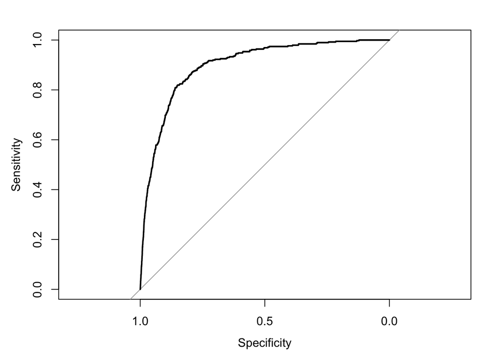

```r
plot(BenchRes$ROC)
```

# Pathway analysis with topology information only

To assess the improvement in the performance by integrating the CGSes into the pasLINCS method, we compare the benchmarking result with that of using only pathway topology but no CGS, which is denoted as “TP” method in our article. Here we show the example R code to identify target pathway of one TS (“LINCSCP_31997”) of a CP and calculate ROC of identifying mTOR signaling pathway for mTOR inhibitors. To compare with the pasLINCS result, we consider the same pathways as the whole candidate pathways.

**Load the CP signature:**

```r
CP_MCF7 <- data.frame(LincsCP$MCF7[,"LINCSCP_31997"],row.names=rownames(LincsCP$MCF7),
                      stringsAsFactors=FALSE)
```

**Load the list of pathways:**

```r
PAS_MCF7 <- PathSigTableList$MCF7
PathwayList<- colnames(PAS_MCF7)[-1]
pathwayTopologies <- AllEdges[AllEdges$Pathway %in% PathwayList,]
```

**Associate CP signatures to pathways:**

```r
Score <- unlist(CalcTPSig(EdgeInfo=pathwayTopologies,data=CP_MCF7,neigen=1))
names(Score) <- unique(pathwayTopologies$Pathway)
```

```r
topPathways<-names(head(sort(Score,na.last=T,decreasing=T),n=5))
topPathways
```

```
## [1] "hsa04650" "hsa05165" "hsa04022" "hsa05166" "hsa05133"
```

**Annotate results of identifying target pathways with pathway names:**

```r
data.frame(PathwayID=topPathways,PathwayName=AllPathwayName[topPathways,"PathwayName"],
           Association=Score[topPathways],stringsAsFactors=FALSE)
```

|  | PathwayID | PathwayName | Association |
| --- | --- | --- | --- |
| hsa04650 | hsa04650 | Natural killer cell mediated cytotoxicity - Homo sapiens (human) | 39.38588 |
| hsa05165 | hsa05165 | Human papillomavirus infection - Homo sapiens (human) | 38.66448 |
| hsa04022 | hsa04022 | cGMP-PKG signaling pathway - Homo sapiens (human) | 29.21126 |
| hsa05166 | hsa05166 | HTLV-I infection - Homo sapiens (human) | 25.21111 |
| hsa05133 | hsa05133 | Pertussis - Homo sapiens (human) | 22.78272 |

**Load the signatures of CPs which inhibit any protein(s) in the pathway of interest:**

```r
PathwayOfInterest <- "hsa04150v2"
mTOR_CP <- TargetPath$Positive$Perturbagen.ID[TargetPath$Positive$Pathway==PathwayOfInterest]
mTOR_CP_SigID <- LincsMeta$MCF7$signatureID[LincsMeta$MCF7$perturbagenID %in% mTOR_CP]
CP_MCF7 <- LincsCP$MCF7[,mTOR_CP_SigID]
```

**Annotate results of benchmarking:**

```r
ScoreTable <- CalcTPSig(EdgeInfo=pathwayTopologies,data=CP_MCF7,neigen=1)
ScoreTable <- ScoreTable[apply(ScoreTable,1,function(x) sum(is.na(x))!=length(x)),]

source("http://eh3.uc.edu/genomics/GenomicsPortals/ilincs/paslincs/BenchPathway.R")
```

```r
BenchRes <- BenchPathway(cordata=ScoreTable,pathway=PathwayOfInterest,
                         metadata=LincsMeta$MCF7,pathlist=rownames(ScoreTable),cutoff=0.9,direction="<")
data.frame(Pathway=PathwayOfInterest,PathwayName=AllPathwayName[PathwayOfInterest,"PathwayName"],
           AUC=BenchRes$AUC,rpAUC=BenchRes$rpAUC,stringsAsFactors=FALSE)
```

| Pathway | PathwayName | AUC | rpAUC |
| --- | --- | --- | --- |
| hsa04150v2 | mTOR signaling pathway - Homo sapiens (human) | 0.6053616 | 1.617998 |

**Plot ROC curve:**

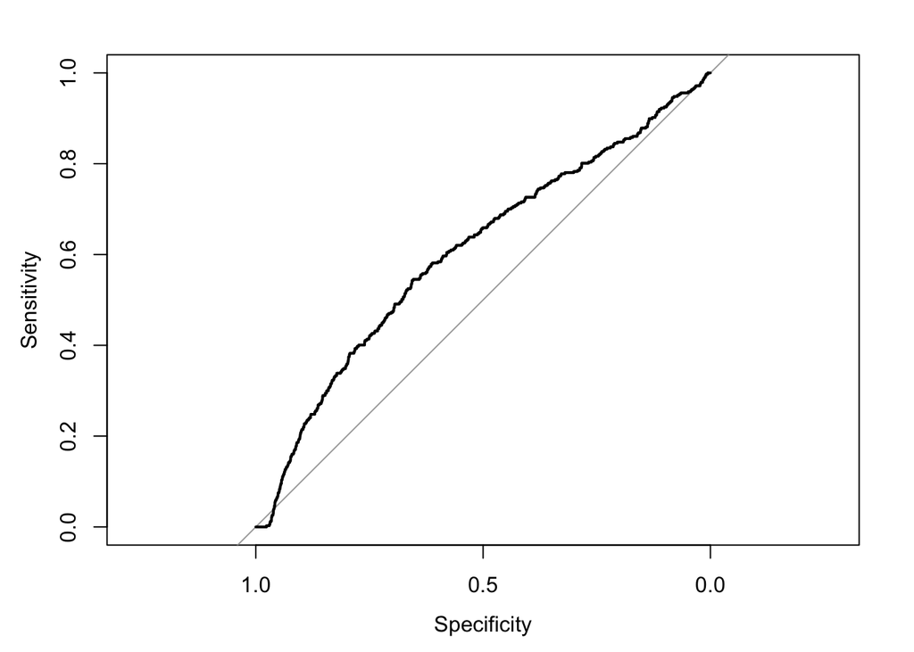

```r
plot(BenchRes$ROC)
```